# Третий этап Индивидуального проекта

Операционные системы - Бекауов А.Т

Российский университет дружбы народов, Москва, Россия

# Введение

## Цель работы

Целью данной работы продолжения редактирования сайта. Выполнить третий этап индивидуального проекта.

# Выполнение лабораторной работы

## Добавление умений и хобби

Первым делом зашёл в реопзиторий Ind_project в content/authors/admin и открыл в текстовом редакторе gedit файл _index.md. Первым делом в этом файле я добавил себе умения и хобби.

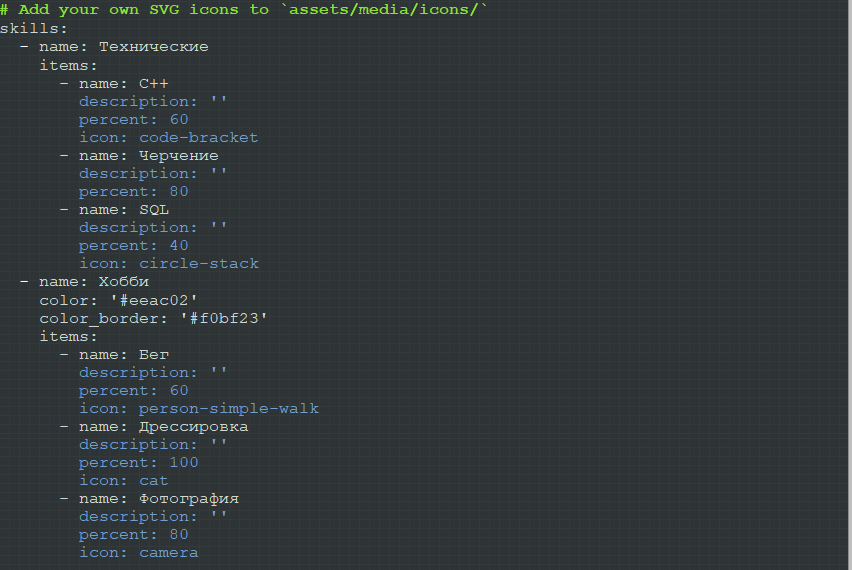

## Добавление опыта работы

В том же файле _index.md ввожу информацию об опыте работы .

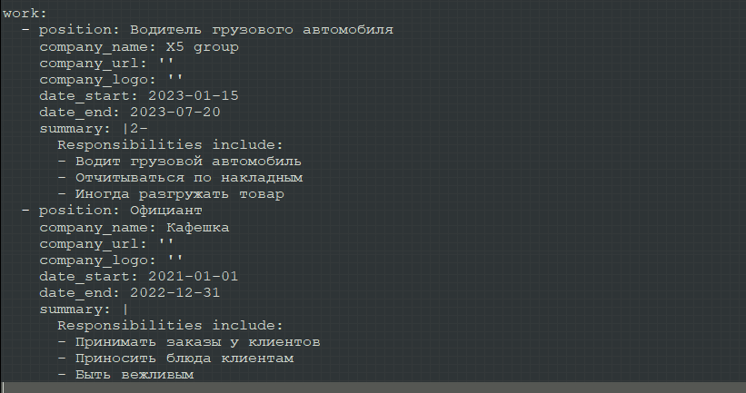

## Добавление достижений

Там же дописываю свои достижения.

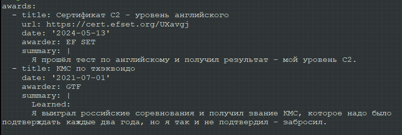

## Пост о прошедшей неделе

Затем перехожу в каталог Ind_project/content/posts и создаю две папки post 3 и post 4 на подобие post 1 и post 2. Открываю папку post 3, открываю в gedit файл index.md и делаю пост о прошедшей неделе.

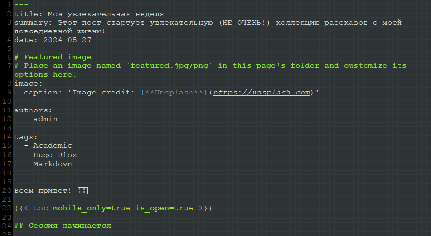

## Пост о Latex

Открываю папку post 4, открываю в gedit файл index.md и делаю пост о Latex

[figure not shown]

## Локальный сервер - проверка постов

Запускаю локальный сервер, с помощью hugo server и проверяю посты.

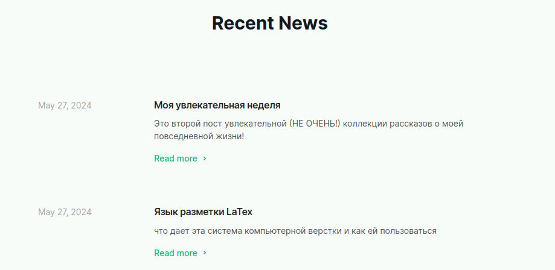

## Перенос изменений на сайт

Ввожу в репозитории Ind_project команду /~/bin/hugo. Далее перехожу в public и отправляю изменения на репозиторий atbekauov.github.io.

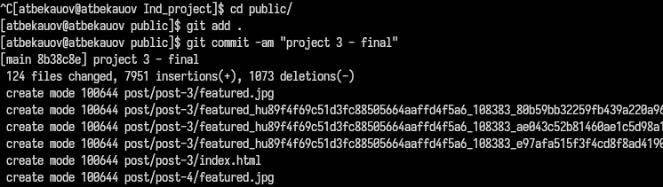

## Проверка сайта - пост про неделю

Захожу на сайт и проверяю пост про неделю.

[figure not shown]

## Проверка сайта - пост про LaTex

Также проверяю пост про Latex.

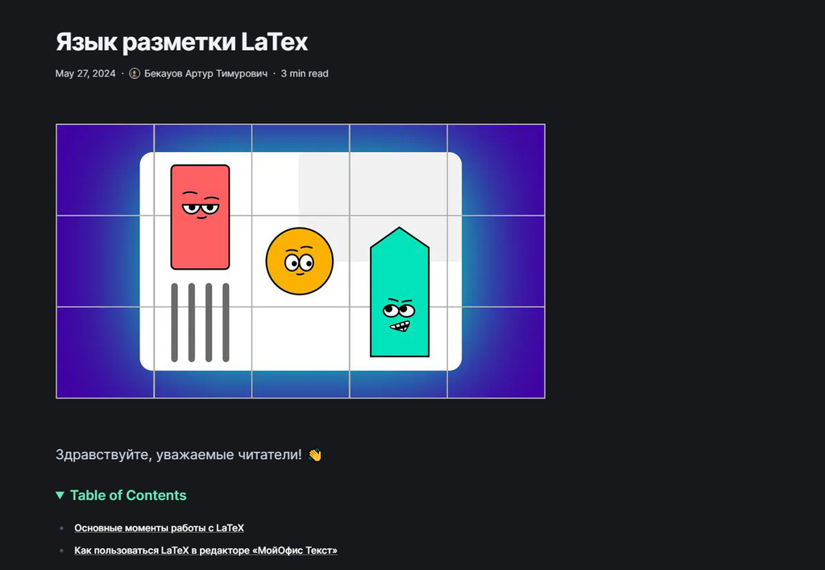

## Проверка сайта - Опыт

Затем проверяю Вкладку Опыт.

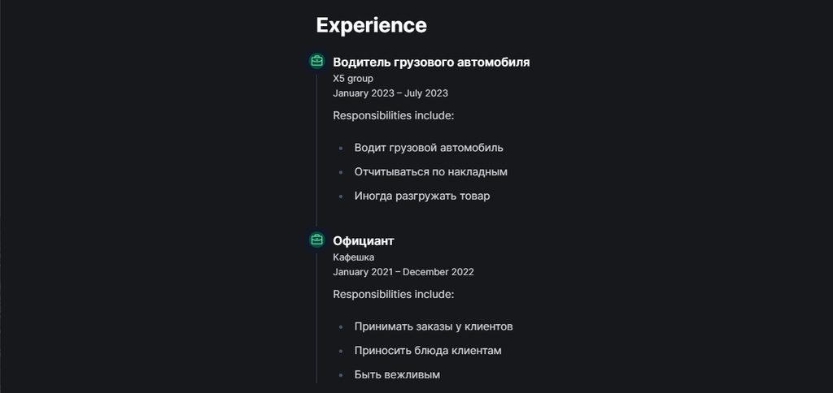

## Проверка сайта - Навыки и достижения

В конце концов проверяю навыки/хобби и достижения

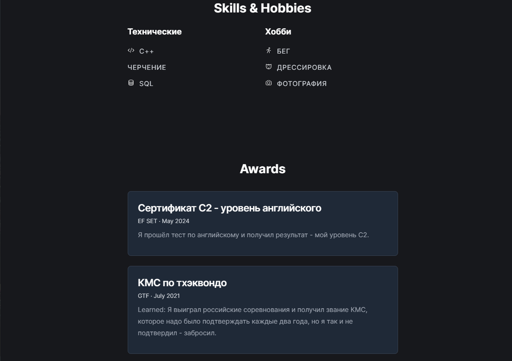

# Заключение